# Algorithm Trading Strategies Project

#### Thomas Haversang

tjh417@nyu.edu

#### Mo Hormozzadeh

mhz241@nyu.edu

#### Arnav Shah

arnav.shah@nyu.edu

### Step 1: Load in And Strucure Data

```python
jpy = pd.read_csv('NYU_USD_JPY_2016.csv',date_parser=pd.to_datetime,parse_dates=[1],index_col  = 1)
x = pd.DataFrame(index = pd.DatetimeIndex(start =jpy.index[0],end =jpy.index[-1],freq='H'))
df= pd.concat([jpy,x],axis =1)
jpy = df.reset_index().dropna().reset_index()
jpy.index = jpy.iloc[:,1].copy()
jpy = jpy.iloc[:,[0,2,3,4]].copy()
jpy.columns = ['Hour #','Ticker','Price','Flow']

xau = pd.read_csv('NYU_XAU_USD_20142015.csv',date_parser=pd.to_datetime,parse_dates=[1],index_col  = 1)
x = pd.DataFrame(index = pd.DatetimeIndex(start =xau.index[0],end =xau.index[-1],freq='H'))
df= pd.concat([xau,x],axis =1)
xau = df.reset_index().dropna().reset_index()
xau.index = xau.iloc[:,1]
xau = xau.iloc[:,[0,2,3,4]].copy()
xau.columns = ['Hour #','Ticker','Price','Flow']

xau_train = xau.iloc[0:int(len(xau)/3):]
xau_test1 = xau.iloc[int(len(xau)/3 + 1):int(len(xau)*2/3)+1]
xau_test2 = xau.iloc[int(2*len(xau)/3 + 1):]


jpy_train = jpy.iloc[0:int(len(jpy)/2):]
jpy_test1 = jpy.iloc[int(len(jpy)/3 + 1):int(len((jpy))*2/3+1)]
jpy_test2 = jpy.iloc[int(len((jpy))*2/3+1):]
```

### Applying Spreads¶

```python
def apply_spread(data_frame,num_spread = 5,spread_size = 50/10000):
    data_frame = data_frame.copy()
    data_frame['Bid'] = data_frame['Price'] - num_spread*spread_size/2
    data_frame['Ask'] = data_frame['Price'] + num_spread*spread_size/2
    return data_frame
```

```python
apply_spread(xau).head()
```

| index | Hour # | Ticker | Price | Flow | Bid | Ask |
| --- | --- | --- | --- | --- | --- | --- |
| 2014-01-02 01:00:00 | 0 | XAU/USD_B | 1222.96 | 2.234127 | 1222.9475 | 1222.9725 |
| 2014-01-02 02:00:00 | 1 | XAU/USD_B | 1222.39 | 1.989209 | 1222.3775 | 1222.4025 |
| 2014-01-02 03:00:00 | 2 | XAU/USD_B | 1221.76 | 1.910035 | 1221.7475 | 1221.7725 |
| 2014-01-02 04:00:00 | 3 | XAU/USD_B | 1221.68 | 1.910035 | 1221.6675 | 1221.6925 |
| 2014-01-02 05:00:00 | 4 | XAU/USD_B | 1217.61 | 1.846154 | 1217.5975 | 1217.6225 |

```python
apply_spread(jpy).head()
```

| index | Hour # | Ticker | Price | Flow | Bid | Ask |
| --- | --- | --- | --- | --- | --- | --- |
| 2016-01-01 17:00:00 | 0 | USD/JPY_B | 120.191 | 1.944591 | 120.1785 | 120.2035 |
| 2016-01-03 18:00:00 | 49 | USD/JPY_B | 120.285 | 1.900000 | 120.2725 | 120.2975 |
| 2016-01-03 19:00:00 | 50 | USD/JPY_B | 120.317 | 1.870539 | 120.3045 | 120.3295 |
| 2016-01-03 20:00:00 | 51 | USD/JPY_B | 120.371 | 1.881090 | 120.3585 | 120.3835 |
| 2016-01-03 21:00:00 | 52 | USD/JPY_B | 120.028 | 1.899257 | 120.0155 | 120.0405 |

# Alpha Strategies¶

## Alpha Strategy 1

A simple mean-reverting trade where we bet that the spread between two simple moving averages will move back together

```python
def Alpha_1(data_frame,lookback1,lookback2,trained_mean = 100, trained_dev=100):
    #lookback1 = 24
    #lookback2= 120
    #lookback mean reverting trade
    data_frame = data_frame.copy()
    data_frame['Alpha'] = (data_frame['Price'].rolling(lookback1).mean() - data_frame['Price'].rolling(lookback2).mean())
    if trained_mean==100:#we are training
        mean = data_frame['Alpha'].mean()
        std = data_frame['Alpha'].std()
        #print('hello')
        #print(mean,std)
        data_frame['Alpha'] = data_frame['Price'].rolling(lookback1).mean() - data_frame['Price'].rolling(lookback2).mean()
        data_frame['Alpha'] =  (data_frame['Alpha'] - mean)/std#z score
        #mean = data_frame['Alpha'].mean()
        #standard_dev = data_frame['Alpha'].std()
        return data_frame,mean,std
    else:
        data_frame['Alpha'] = data_frame['Price'].rolling(lookback1).mean() - data_frame['Price'].rolling(lookback2).mean()
        data_frame['Alpha'] =  (data_frame['Alpha'] - trained_mean)/trained_dev#z score

        #print('hello')
        return data_frame,trained_mean,trained_dev
```

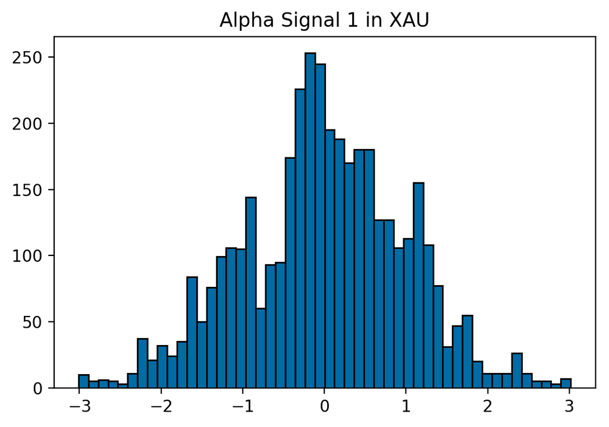

```python
df1,trained_mean_xau1,trained_dev_xau1 = Alpha_1(data_frame=apply_spread(xau_train),lookback1 = 24,lookback2=120)
plt.figure(figsize = (6,4),dpi =200)
plt.hist(df1['Alpha'],edgecolor = 'k',bins = 50);
plt.title('Alpha Signal 1 in XAU');
```

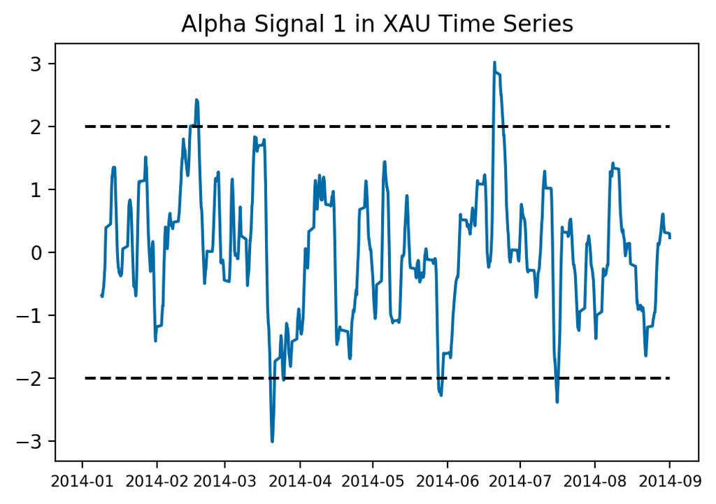

```python
plt.figure(figsize = (6,4),dpi =200)
plt.plot(df1['Alpha'])
plt.title('Alpha Signal 1 in XAU Time Series')
plt.plot([df1.index[0],df1.index[-1]],[2,2],'--k')
plt.plot([df1.index[0],df1.index[-1]],[-2,-2],'--k')
plt.xticks(fontsize =8);
```

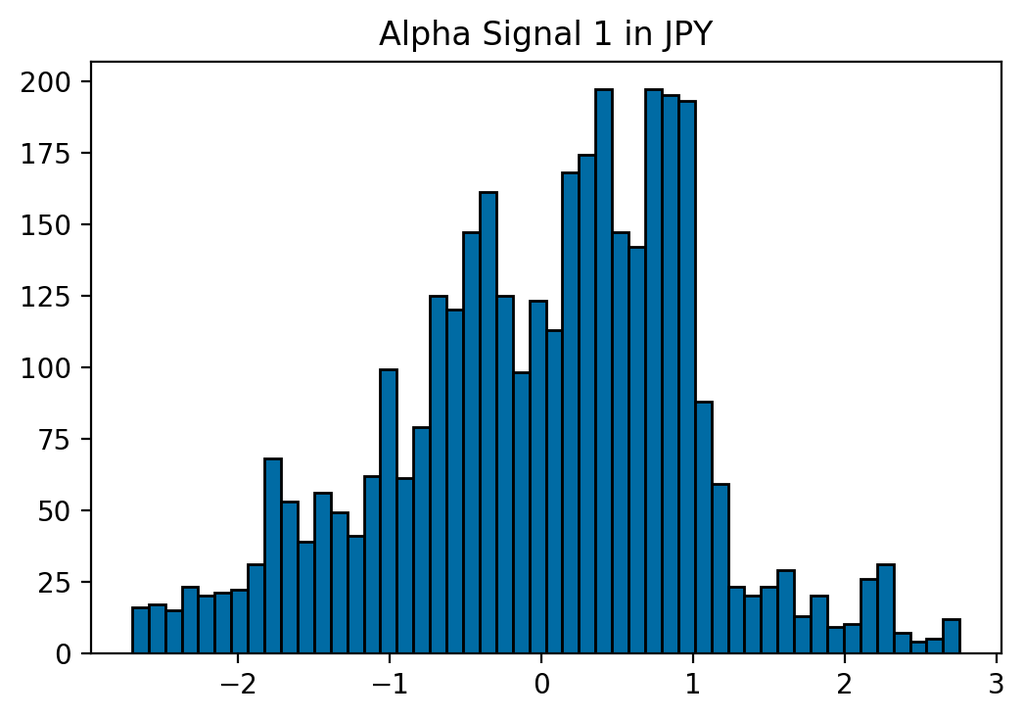

```python
df1_jpy,trained_mean_jpy_1,trained_std_jpy_1 = Alpha_1(data_frame=apply_spread(jpy_train),lookback1 = 24,lookback2=120)
plt.figure(figsize = (6,4),dpi =200)
plt.hist(df1_jpy['Alpha'],edgecolor = 'k',bins = 50);
plt.title('Alpha Signal 1 in JPY');
```

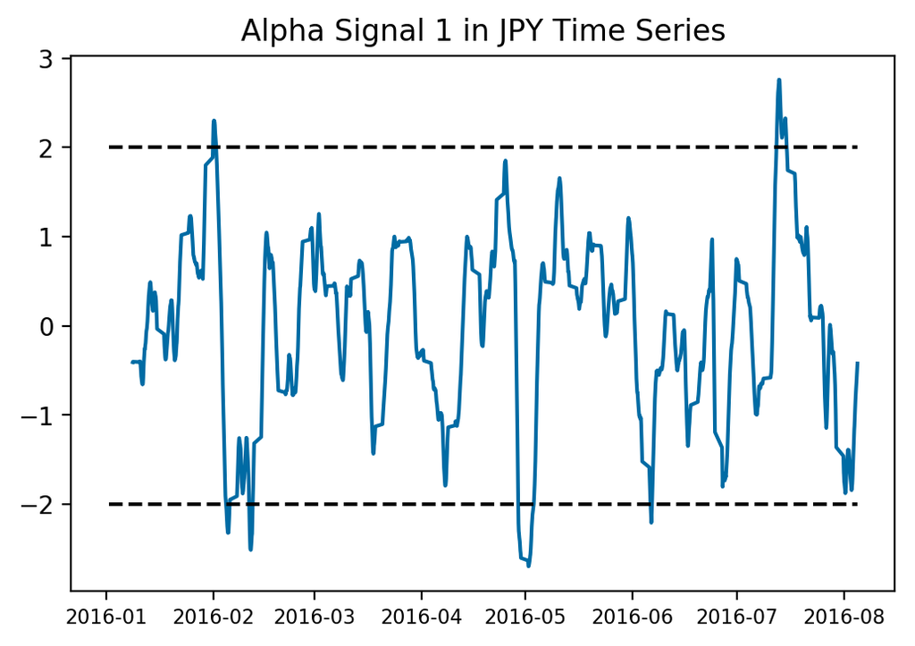

```python
plt.figure(figsize = (6,4),dpi =200)
plt.plot(df1_jpy['Alpha'])
plt.title('Alpha Signal 1 in JPY Time Series')
plt.plot([df1_jpy.index[0],df1_jpy.index[-1]],[2,2],'--k')
plt.plot([df1_jpy.index[0],df1_jpy.index[-1]],[-2,-2],'--k')
plt.xticks(fontsize =8);
```

# Alpha Signal 2

This strategy is exmaining whether or not we can capture momentum, when the change in the simple moving average is very high.

```python
def Alpha_2(data_frame,lookback1,trained_mean =100,trained_dev = 100):
    #lookback1 = 24
    #lookbacl2 = 120
    data_frame = data_frame.copy()
    #lookback = halflife

    data_frame['Alpha'] = -data_frame['Price'].rolling(lookback1).mean().diff()# - data_frame['Price'].rolling(lookback2).mean()

    if trained_mean ==100:
        mean = data_frame['Alpha'].mean()
        std =  data_frame['Alpha'].std()
        data_frame['Alpha'] =  -(data_frame['Alpha'] - mean)/std#z score
        return data_frame,mean,std
    else:
        data_frame['Alpha'] =  -(data_frame['Alpha'] - trained_mean)/trained_dev#z score
        return data_frame,trained_mean,trained_dev


    """sig_boost= data_frame['Flow'].rolling(lookback1).mean()
    sig_boost=(sig_boost - sig_boost.mean())/sig_boost.std()
    sig_boost.loc[sig_boost>1.45]=1.25
    sig_boost.loc[sig_boost<1.5]=1.25
    sig_boost = sig_boost.fillna(1)
    data_frame['Alpha'] = data_frame['Alpha']*sig_boost """
    return data_frame
```

## Alpha Signal 3

A joint requirment where the change in the flow and the prices have to be significant.

```python
def Alpha_3(data_frame,lookback1 =240,bound = 0.5,trained_mean = 100,trained_dev =100):
    df = data_frame.copy()
    sig1 = df['Flow'].rolling(lookback1).mean().diff()
    sig2 = df['Price'].rolling(lookback1).mean().diff()
    combined_signal = pd.concat([sig1,sig2],axis =1)

    means = combined_signal.mean()
    std_devs = combined_signal.std()
    normed_signal = (combined_signal - means)/std_devs

    if type(trained_mean) != int:

            #return normed_signal,means,std_devs
        means = trained_mean
        std_devs = trained_dev
        normed_signal = (combined_signal - means)/std_devs

    filtered_signal = normed_signal.loc[((normed_signal.Flow>bound) & (normed_signal.Price>bound)) | ((normed_signal.Flow<-bound) & (normed_signal.Price<-bound))]

    x = pd.Series(index =df.index)
    x.loc[filtered_signal.index] = -filtered_signal.Price
    x =x.fillna(0)
    df['Alpha'] = x
    return df,means,std_devs
```

## Alpha Signal 4

A simple regression on the change in flow and its ability to forecast a change in price in assets.

```
Slope = -26.935814858079574
Intercept = 0.5931579634039398
Rsq = 0.6037619819555625
```

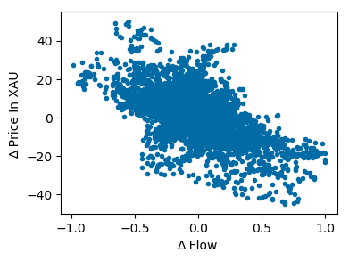

```python
plt.figure(figsize = (4,3),dpi =100)
plt.plot(x,y,'.')
plt.xlabel('∆ Flow ')
plt.ylabel('∆ Price In XAU ')
print('Slope =', linregress(x,y)[0])
print('Intercept =', linregress(x,y)[1])
print('Rsq =', linregress(x,y)[4])
```

```
Slope = -1.6147072612341502
Intercept = -0.17068528637897104
Rsq = 0.04359414733738701
```

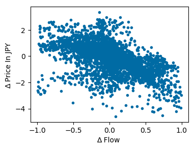

```python
plt.figure(figsize = (4,3),dpi =100)
plt.plot(x,y,'.')
plt.xlabel('∆ Flow ')
plt.ylabel('∆ Price In JPY ')
print('Slope =', linregress(x,y)[0])
print('Intercept =', linregress(x,y)[1])
print('Rsq =', linregress(x,y)[4])
```

```python
def Alpha_4(test_data,inst = 'xau',trained_mean =100,trained_dev = 100):
    df = test_data.copy()
    if inst =='xau':
        slope = -26.935814858079574
        intercept = 0.5931579634039398
    else:
        slope = -1.6147072612341502
        intercept = -0.17068528637897104

    change_in_flow = df['Flow'].diff(48).fillna(0)
    change_in_flow.loc[(change_in_flow<-1) | (change_in_flow>1)]=0
    forecasted_price_change = slope*change_in_flow + intercept
    if trained_mean ==100:
        mean = forecasted_price_change.mean()
        std_dev = forecasted_price_change.std()
        z_scored = (forecasted_price_change - mean)/std_dev
    else:
        mean = trained_mean
        std_dev = trained_dev

        z_scored = (forecasted_price_change - forecasted_price_change.mean())/forecasted_price_change.std()


    df['Alpha'] = z_scored
    return df,mean,std_dev
```

# Training Alpha Parameters

We use our training data sets in JPY and XAU to determine the mean and standad deviation parameters we will use in future z-scores.

```python
trained_params
```

|  | Trained Mean | Trained Stdev |
| --- | --- | --- |
| Alpha 1 | 1.04937 | 14.1919 |
| Alpha 2 | -0.0130005 | 0.134552 |
| Alpha 3 | [0.0002143210921930481, 0.013000454899921687] | [0.0036525341203754056, 0.13455178092046627] |
| Alpha 4 | 0.484575 | 7.94792 |

```python
trained_params_jpy
```

|  | Trained Mean | Trained Stdev |
| --- | --- | --- |
| Alpha 1 | -0.259567 | 1.02206 |
| Alpha 2 | 0.00420403 | 0.0115135 |
| Alpha 3 | [0.00013157164495899865, -0.004204025566811367] | [0.004828451073462072, 0.011513484506582806] |
| Alpha 4 | -0.186078 | 0.598879 |

### Examining Alpha Correlations

Checking out if we have highly uncorrelated, or highly correlated parameters in our testing data

#### XAU

```python
corr_mat = pd.concat([df1['Alpha'],df2['Alpha'],df3['Alpha'],df4['Alpha']],axis=1).dropna()
corr_mat.columns= np.arange(1,5,1)
corr_mat.corr()
```

|  | 1 | 2 | 3 | 4 |
| --- | --- | --- | --- | --- |
| 1 | 1.000000 | 0.861282 | -0.007702 | 0.252909 |
| 2 | 0.861282 | 1.000000 | -0.016270 | 0.257120 |
| 3 | -0.007702 | -0.016270 | 1.000000 | 0.005327 |
| 4 | 0.252909 | 0.257120 | 0.005327 | 1.000000 |

#### JPY

```python
corr_mat = pd.concat([df1_j['Alpha'],df2_j['Alpha'],df3_j['Alpha'],df4_j['Alpha']],axis=1).dropna()
corr_mat.columns= np.arange(1,5,1)
corr_mat.corr()
```

|  | 1 | 2 | 3 | 4 |
| --- | --- | --- | --- | --- |
| 1 | 1.000000 | 0.665183 | 0.004365 | 0.177288 |
| 2 | 0.665183 | 1.000000 | -0.181278 | 0.066439 |
| 3 | 0.004365 | -0.181278 | 1.000000 | 0.057494 |
| 4 | 0.177288 | 0.066439 | 0.057494 | 1.000000 |

## Alpha Pocessing and Order Engine

The alpha processes outputs the number of units we should be long, or short. Generally, this function is bounded, in that we will only go long position exceeds some bound in the alpha z-scores.

```python
def process_alphas_hold(alpha_df,hold_time = 48,boundary =1,scale =250,position_cap =250):
    #if our forecased_price change is>2 standard deviations, buy
    df = alpha_df.copy()
    alphas = df['Alpha'].copy()
    order_df = pd.Series(0,index = df.index)
    i = 0
    order =0
    while i<len(alphas):
        #print(i)
        sig = alphas.iloc[i]
        if sig>boundary:#long
            order = order + scale*sig
            order_df.iloc[i:i+hold_time+1] =order# hold for 48 hours
            i = i+hold_time
        if sig<-boundary:#short
            order = order +scale*sig
            order_df.iloc[i:i+hold_time+1] =order
            i = i+hold_time
        else:
            order =0
        i=i+1
    order_df.loc[order_df>position_cap]=position_cap
    order_df.loc[order_df<-position_cap] = -position_cap
    df['Target Position'] = order_df.copy()
    df['Current Position'] = df['Target Position'].shift(1).fillna(0)
    df['Order'] = df['Target Position']- df['Current Position']
    return df
```

```python
def process_order(df_row):
    row = df_row.copy()
    bid = row.iloc[4]
    ask = row.iloc[5]
    order = row.iloc[-1]

    if order>0:#buy at ask
        #print('buy')
        cf = -order*ask
        spread_paid = order*(ask-bid)/2

        return pd.Series([cf,spread_paid],index=['Cash Flow','Spread Paid'])
    if order<0:
        spread_paid = -order*(ask-bid)/2
        cf = -order*bid

        return pd.Series([cf,spread_paid],index=['Cash Flow','Spread Paid'])
    else:
        return pd.Series([0,0],index=['Cash Flow','Spread Paid'])
```

# Evaluating Performance On Test Data

## Strategy 1

JPY

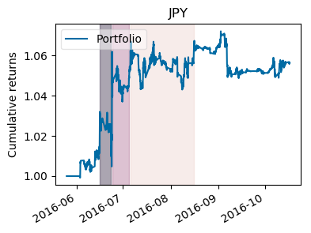

|  | Statistics |
| --- | --- |
| IR | 1.540909 |
| Calmar Ratio | 1.043227 |
| Max Drawdown | -0.026389 |
| Total Return | 0.056298 |

```python
plt.figure(figsize=(4,3),dpi =100)
pf.plot_drawdown_periods(returns,top=3)
plt.title('JPY')
plt.show()
metrics
```

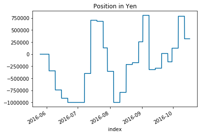

```python
simulation_1['Current Position'].plot()
plt.title('Position in Yen')
```

#### XAU

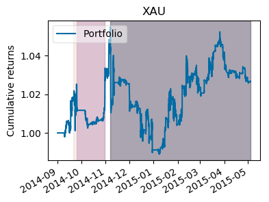

|  | Statistics |
| --- | --- |
| IR | 0.537292 |
| Calmar Ratio | 0.127896 |
| Max Drawdown | -0.062335 |
| Total Return | 0.026729 |

```python
plt.figure(figsize=(4,3),dpi =100)
pf.plot_drawdown_periods(returns,top=3)
plt.title('XAU')
plt.show()
metrics
```

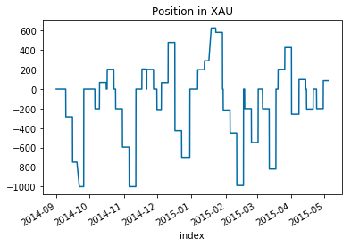

```python
simulation_1['Current Position'].plot()
plt.title('Position in XAU')
```

## Strategy 2

[figure not shown]

|  | Statistics |
| --- | --- |
| IR | -0.026735 |
| Calmar Ratio | NaN |
| Max Drawdown | -7.266338 |
| Total Return | -10.597000 |

```python
plt.figure(figsize=(4,3),dpi =100)
pf.plot_drawdown_periods(returns,top=3)
plt.title('JPY')
plt.show()
metrics
```

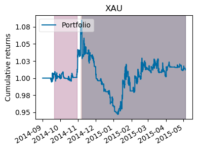

|  | Statistics |
| --- | --- |
| IR | 0.220636 |
| Calmar Ratio | 0.029669 |
| Max Drawdown | -0.127214 |
| Total Return | 0.012572 |

```python
plt.figure(figsize=(4,3),dpi =100)
pf.plot_drawdown_periods(returns,top=3)
plt.title('XAU')
plt.show()
metrics
```

#### Strategy 4

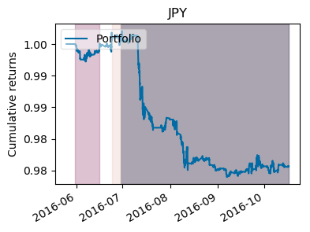

|  | Statistics |
| --- | --- |
| IR | -3.220445 |
| Calmar Ratio | -0.425025 |
| Max Drawdown | -0.023022 |
| Total Return | -0.019352 |

```python
plt.figure(figsize=(4,3),dpi =100)
pf.plot_drawdown_periods(returns,top=3)
plt.title('JPY')
plt.show()
metrics
```

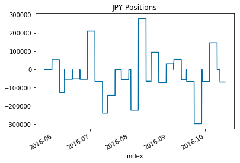

```python
simulation_1['Target Position'].plot(title = 'JPY Positions')
```

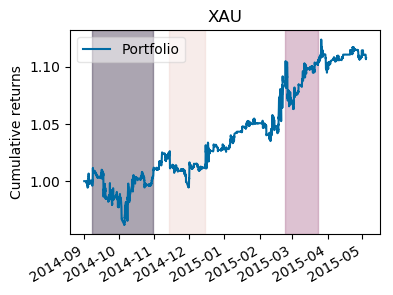

|  | Statistics |
| --- | --- |
| IR | 1.482973 |
| Calmar Ratio | 0.628098 |
| Max Drawdown | -0.049334 |
| Total Return | 0.107699 |

```python
plt.figure(figsize=(4,3),dpi =100)
pf.plot_drawdown_periods(returns,top=3)
plt.title('XAU')
plt.show()
metrics
```

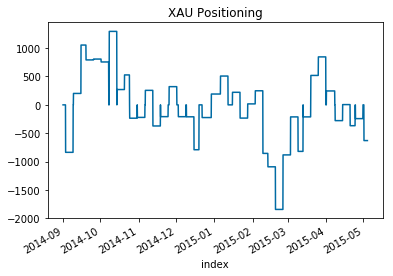

```python
simulation_1['Target Position'].plot(title = 'XAU Positioning')
```